# HW04 Part 2

Christina Beauford

27 December 2018

```r
library(tidyverse)
```

####Plot 1

```r
data(trees)
```

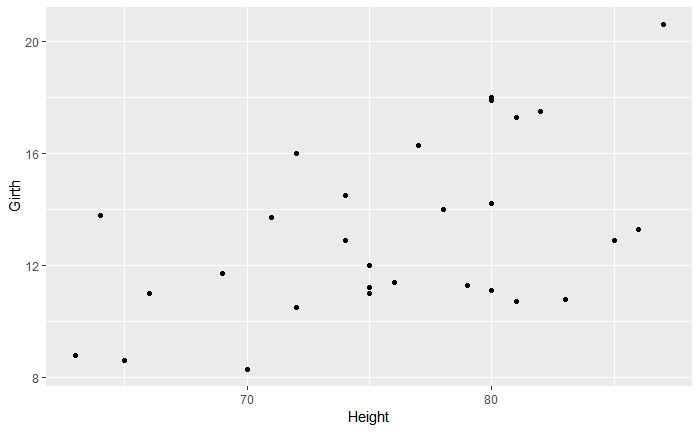

```r
ggplot(data = trees, mapping = aes(x = Height, y = Girth)) +
  geom_point()
```

####Plot 2

```r
year <- (1821:1934)
pelts <- as.vector(lynx)
lynx_pelts <- data.frame(year, pelts)
```

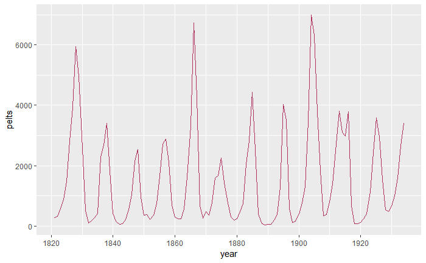

```r
ggplot(data = lynx_pelts, mapping = aes(x = year, y = pelts)) +
  geom_line(color = "maroon")
```

####Plot 3

```r
data(iris)
```

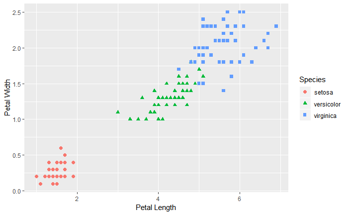

```r
ggplot(data = iris, mapping = aes(x = Petal.Length, y = Petal.Width, shape = Species, color = Species)) +
  geom_point(size = 2) +
  labs(x = "Petal Length", y = "Petal Width")
```

The species “virginica” has larger petals than the other species. The species “versicolor” has the next largest and “setosa” has the smallest petals. This graph shows the general trend of having increased petal width with an increased petal length.

####Plot 4 and 5

```r
data(msleep)
```

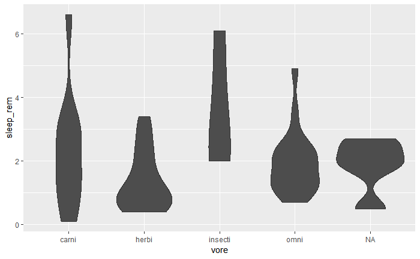

```r
ggplot(data = msleep, mapping = aes(x = vore, y = sleep_rem)) +
  geom_violin(fill = "gray30")
```

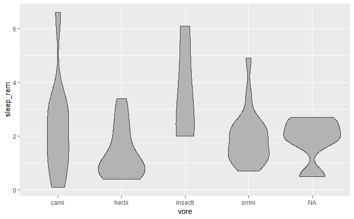

```r
ggplot(data = msleep, mapping = aes(x = vore, y = sleep_rem)) +
  geom_violin(fill = "gray70")
```

A violin plot mixes a boxplot with the density plot. It is a “compact display of a continuous distribution”. It uses the wider areas to show emphasis on what the data is for the majority of the data shows. The difference in the two types of gray colors is how dark the gray shading is.This graph shows that generally, the vore “insecti” gets the most rem sleep.

####Plot 7

```r
data(msleep)
```

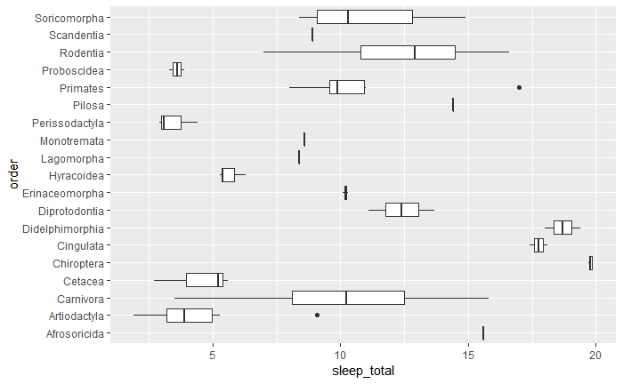

```r
ggplot(data = msleep, mapping = aes(x = order, y = sleep_total)) +
  geom_boxplot() +
  coord_flip()
```

This graph shows the “Chiroptera” gets the most sleep total, while the “Artiodactyla” gets the least sleep total.

####Plot 8

```r
data(msleep)
```

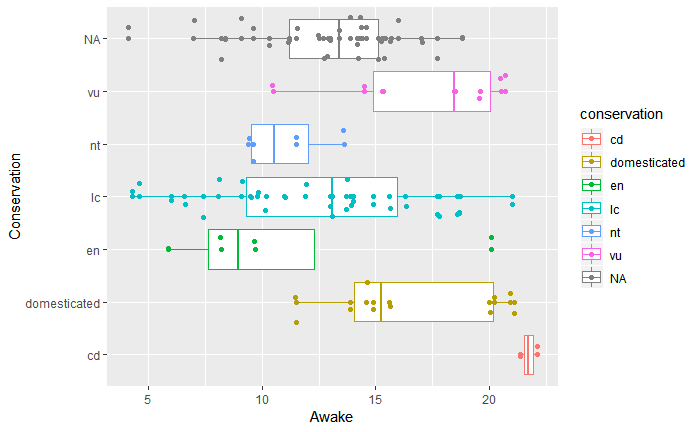

```r
ggplot(data = msleep, mapping = aes(x = conservation, y = awake, color = conservation)) +
  geom_boxplot() +
  geom_point() +
  geom_jitter() +
  labs(x = "Conservation", y = "Awake") +
  guides(fill = guide_legend(title = "Conservation")) +
  coord_flip()
```

This graph shows that generally, the “cd” conservation spends the most time awake, followed closely by the “vu” and “domesticated” conservations.

####Plot 9

```r
data(msleep)
```

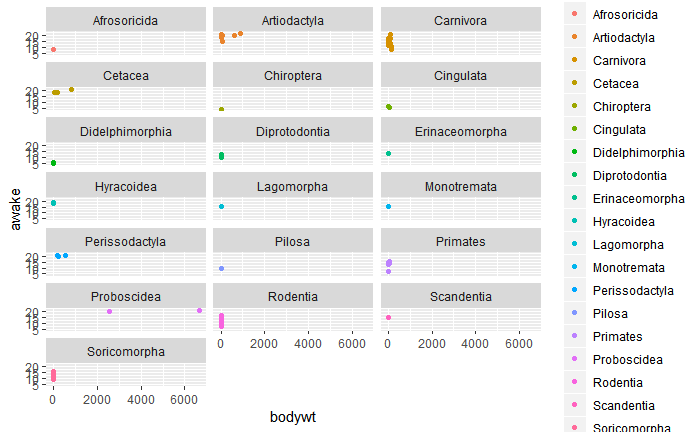

```r
ggplot(data = msleep, mapping = aes(x = bodywt, y = awake, color = order)) +
  geom_point() +
  facet_wrap(~order, ncol = 3)
```

The “Chiroptera” spends the least time awake compared to the rest of the orders. The “Proboscidea” have the highest body weights and spend 20 or more hours awake.

####Plot 10

```r
data(msleep)
```

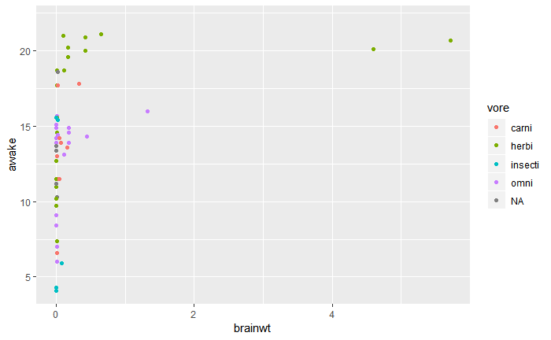

```r
ggplot(data = msleep, mapping = aes(x = brainwt, y = awake, color = vore)) +
  geom_point()
```